# Research questions

Ha Bui

4/8/2021

# RQ 1 - how interested are teachers in teaching CS? And, how does this differ by familiarity (RQ1a), grade level (1b), and urban/rural status (1c)?

## Quant - familiar

### Teacher districts–> this can be used to determine the urban and rural schools

#**Still need the data for rural, urban, etc for where the teachers are located**

| INTEREST IN CS | n | percent |
| --- | --- | --- |
| Moderately interested | 119 | 47.98% |
| Very interested | 81 | 32.66% |
| Not at all interested | 48 | 19.35% |
| Total | 248 | - |

## Teacher familiarity in CS standard

### Teachers that self-report being “very familiar” is only 6.8% of the 251 teachers surveyed.

#### Initial thoughts included: are teachers really not familiar with the standards, is their self-efficacy that low when it comes to the implementation of CS standards due to the extent of the field of technology?

| FAMILIAR | n | percent |
| --- | --- | --- |
| Not at all familiar | 111 | 0.4457831 |
| Slightly familiar | 121 | 0.4859438 |
| Very familiar | 17 | 0.0682731 |

# Interest in CSE

## Teachers have an interest in CS. As an initial look at the teachers interest in CS, **80.6%** of teachers surveyed had some interest in CS. This statisitic still leaves almost **20%** of teachers that have no interest in CS.

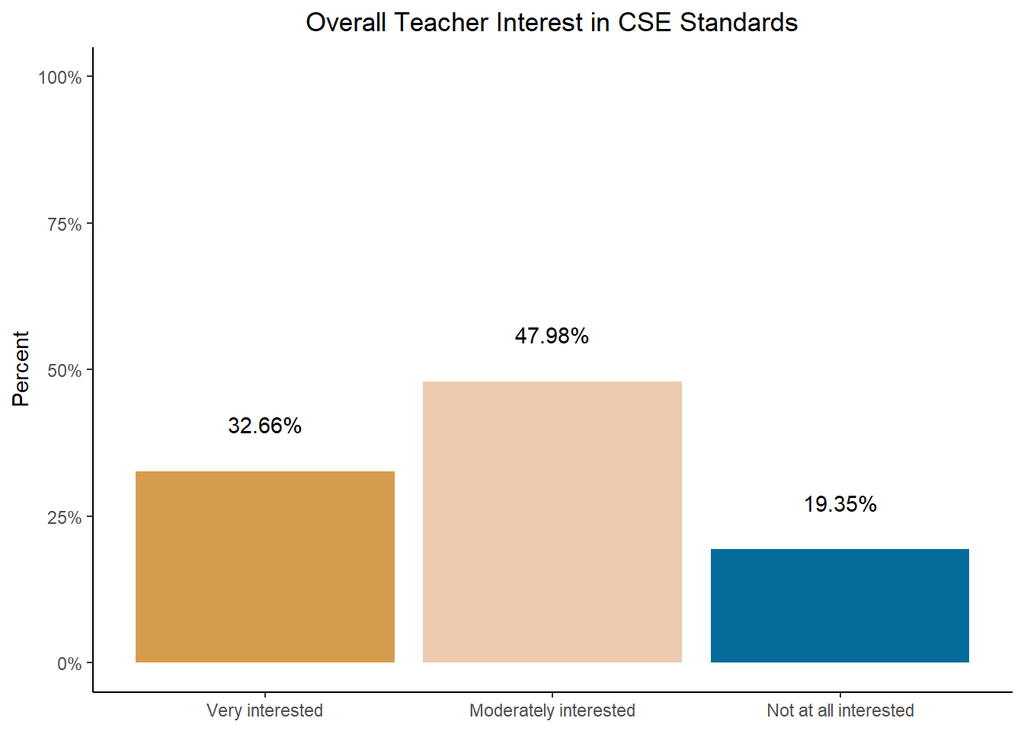

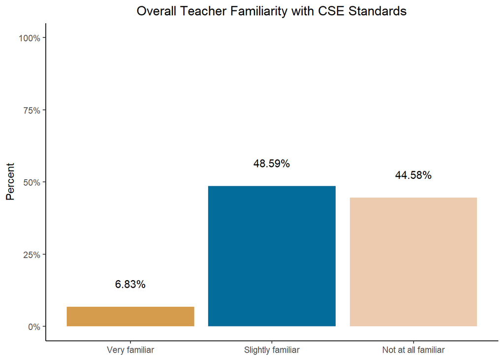

## Teacher Interest in CS by familiarity

### This section is divided into familiar and not familiar with the computer science standards. Familiar is the combined responses of “Very Familiar” and “Slightly Familiar”

#### Familiar = 138, Not at all Familiar = 111

### Nearly half of teachers that are familiar with the CS standards are Very interested in teaching CS **48.2%*) **and *moderately interested*** 44.5% **->** 92.7%** of teachers that are under the combined “FAMILIAR” category has some interest in teaching cS.

### Teachers that are not familiar with CS standards, only **13.5%** are *very interested* and **52.3%** are *moderately interested* in teaching CS.

#### Teachers that are familiar with the Tennessee CS standards are more likely to be interested in teaching CS. There are several different possibilities for these occurances. First, teachers are not willing to jump into a subject they are not familiar with and be trained when they do not know what they will have to know, be proficient, and teach like and “expert” to their students. Second, teachers may not be interested in changing what they teach, even though **92.7%** of teachers that are familiar with CS standards were willing to teach CS, there is still **7%** of teachers that are familiar with the standards that are not interested in teaching CS at all. There could be a myriad of reasons that teachers want to teach or do not want to teach CS.

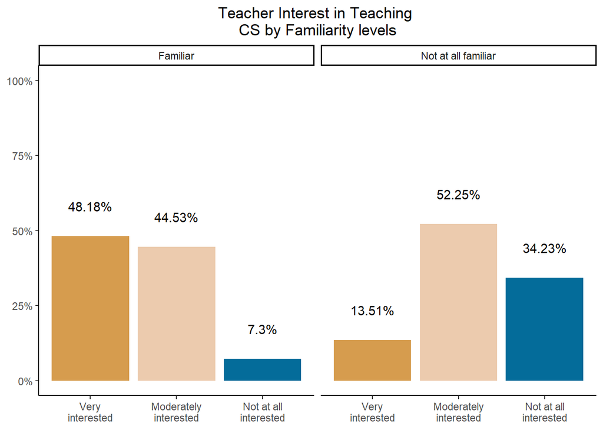

# This table shows teacher familiarity in non-combined format **can be removed** ## Only 17 teachers are very familiar with the standards, but none these teachers were **“Not at all interested”** in CS. ### *A further investigation in to what subjects they currently teach can help to clarify these results*

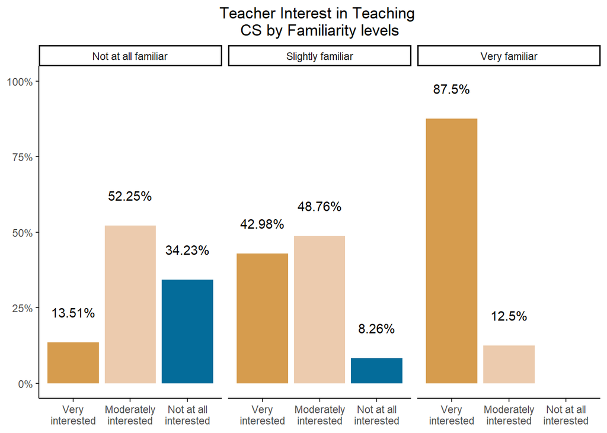

```
##   T_SCHOOL_TYPE   n
## 1          Both  14
## 2    Elementary 145
## 3        Middle  87
## 4 Neither/Other   3
```

#### There is very little difference when exploring interest by school type and teachers that are not interested in cS.

#### Teachers that are not interested in CS elementary **(n=145, 17.4%)**, middle **(n=87, 21.8%)** are the minority of teachers that were surveyed. There is interest in CS implementation, but there seems to be barriers to teachers feeling prepared to either teacher or integrate CS into their classrooms.

[figure not shown]

# RQ 2 - what problems (2a) or barriers (2b), if any, do teachers anticipate concerning teaching CS?

## Qual - barriers

### **Question:** In your opinion, how much of a problem or barrier is each of the following for your computer science instruction in your class/school?

### Teachers identified *lack of time*, *CS knowledge*, and *CS resources* as a problems for CS instruction in schools.These three problems are the most prominent with teachers. This later illustrated when teachers were asked open-ended questions about what barriers there are to implement CS instruction. Teacher felt that *time*, *training*, and *resources* were the big barriers to CS implementation. These are recurring themes throughout the survey, teachers need training and resources to feel that they are better prepared to take on the challenges that come with implementing CS. When the mean of teacher responses are evaluated we see that *lack of time* (2.46 ± 0.67 ), *CS knowledge* (2.29 ± 0.67), and *CS resources* (2.28 ± 0.65) more often fall under the *Somewhat of a Problem* to *A Serious Problem*.

### Teachers also indicated, on average, that there was not a significant problem with *reliable internet* (1.70 ± 0.74) or *power sources for devices*(1.63 ± 0.75).

1: Not a Significant Problem 2: Somewhat of a Problem 3: A Serious Problem

|  | 1 | 2 | 3 |
| --- | --- | --- | --- |
| Lack of reliable access to the Internet. | 102 | 78 | 37 |
| Lack of functioning computing devices (for example: desktop computers, laptop computers, tablets, smartphones). | 70 | 80 | 67 |
| Insufficient power sources for devices (for example: electrical outlets, charging stations). | 116 | 66 | 35 |
| Lack of support to maintain technology (for example: repair broken devices, install software). | 93 | 80 | 44 |
| Lack of time. | 22 | 74 | 121 |
| Lack of computer science knowledge. | 26 | 103 | 88 |
| Lack of computer science resources. | 23 | 109 | 84 |

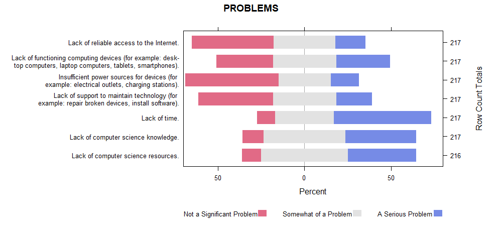

### Average and standard deviation by rows

#### Teachers responses that are less than mean of **2** are no a serious problem, but those that are close to or more than **2** are categorized as a serious problems, in teachers’ perspectives.

```
## # A tibble: 0 x 0
```

| measure | mean | sd |
| --- | --- | --- |
| Lack of time. | 2.46 | 0.67 |
| Lack of computer science knowledge. | 2.29 | 0.67 |
| Lack of computer science resources. | 2.28 | 0.65 |
| Lack of functioning computing devices (for example: desktop computers, laptop computers, tablets, smartphones). | 1.99 | 0.80 |
| Lack of support to maintain technology (for example: repair broken devices, install software). | 1.77 | 0.76 |
| Lack of reliable access to the Internet. | 1.70 | 0.74 |
| Insufficient power sources for devices (for example: electrical outlets, charging stations). | 1.63 | 0.75 |

```
## # A tibble: 10 x 5
##    category         code1 code2 code3 code_total
##    <chr>            <dbl> <dbl> <dbl>      <dbl>
##  1 DNA                  9     0     0          9
##  2 none/unsure         15     0     0         15
##  3 PD/training         55     0     0         55
##  4 PD/training,         1     0     0          1
##  5 resources           80    14     0         94
##  6 student interest     1     0     0          1
##  7 student skill        6     3     1         10
##  8 support              2     1     0          3
##  9 time                56    27     3         86
## 10 <NA>                33   213   254        500
```

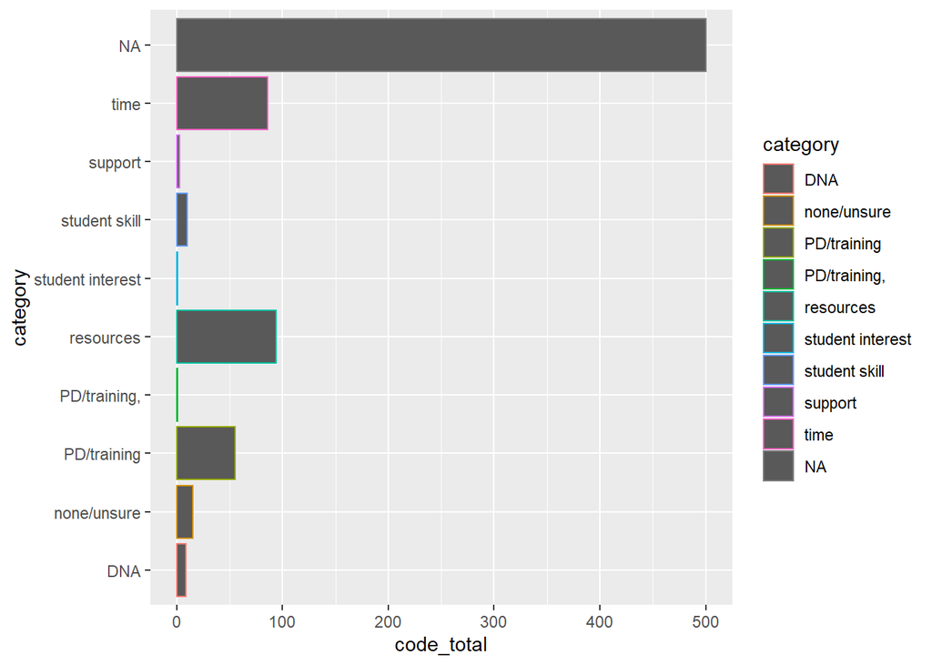

# RQ 3 - what would teachers find useful (3a) or what would they want in PD (3b) to teach CS?

## Qual - what they want to see

### **Question:** If you were to attend a computer science-related professional development session, how useful would you find the following?

1: Not at all useful 2: Slightly useful 3: Moderately useful 4: Very useful 5: Extremely useful

### To determine if category is significant there needs to have at least 63 participants (25%) selected that category.

#### Having 63 (25%) of participants selecting a category will ensure that there is more than an even split between the answers.

**May need to shift the minimum requirement for significance, but this is my initial thoughts due to not wanting there to be an even split between the 5 answers at 20% and none of the responses give us insight.** **Respondents did not find the resources significantly “Not at all useful”. The resource that had the highest “Not at all useful” response was “Lessons or resources from websites that have a subscription fee or per lesson cost” which had 23 responses (9%)**.

## Results of the Usefulness question

### When asked the usefulness of published text book there was a split across the responses. The most responses were **“Moderately useful”** (n=54,22%), not reaching the level of significance set at at least (n=63).

### Teacher felt that developed units and lessons were **“Very useful”** (n=71, 28%). When teachers begin a new subject it can be disconcerting not having taught before and by having pre-developed units and lessons can ease that initial resistance and/or reservations to teaching a new subject or integrating CS.

### Teacher felt that online CS units or courses where students could self-pace were **“Very useful”** with 78 responses (31%). With the growing focus on meeting the needs of divers learners having a digital CS unit or course could meet the needs of students with many different learning levels.

### There was not a clear answer for teachers’ perceptions on paid resources or lessons. Though this question did have the greatest number of responses for **“Not at all useful”** (n=23,9%).

### Teachers felt that lessons and resources that are free are the most useful. With 74 respondents (29%) find free resources **“Very useful”** while 70 respondents (28%) found free resources **“Extremely useful”**, While none of the respondents found the free resources **“Not at all useful”**. For this question, I think about how teachers love free stuff that can help their students and themselves learn and develop. Especially when teachers have access to free resources they can have a stockpile of sites that they can send students when they are in need of extra help that is beyond what the teacher can accomplish on their own.

### Teachers felt that lessons they created by themselves or with others were **“Very useful”** (n=72, ~29%) of respondents. **Looking back at this question it should have been divided into two questions (lesson created by self and lessons created by/with others)**. When I was assigned to a new class or curriculum, the initial time I felt significantly less stress when I was utilizing lessons created by others and slowly altered the lessons to fit my teaching style and other factors.

### Teachers felt that the ectera sources were **“Very useful”** (n=78, 31%). This section is the catch all and I am not sure how to analyze this section. *This would be a good question to get more information on, especially if we can discuss with some of the individuals.*

|  | 1 | 2 | 3 | 4 | 5 |
| --- | --- | --- | --- | --- | --- |
| Commercially published textbooks (printed or electronic), including the supplementary materials (for example: worksheets) that accompany the textbooks. | 9 | 34 | 54 | 46 | 30 |
| State, county, or district developed units or lessons. | 7 | 16 | 48 | 71 | 31 |
| Online units or courses that students work through at their own pace (for example: MOOCs, EdX, IMACS). | 3 | 16 | 30 | 78 | 46 |
| Lessons or resources from websites that have a subscription fee or per lesson cost (for example: BrainPOP, Discovery Ed, Teachers Pay Teachers). | 23 | 19 | 37 | 61 | 33 |
| LLessons or resources from websites that are free (for example: Khan Academy, code.org). | 0 | 8 | 21 | 74 | 70 |
| Units or lessons you created (either by yourself or with others). | 11 | 20 | 39 | 72 | 31 |
| Units or lessons you collected from any other source (for example: conferences, journals, colleagues, university or museum partners). | 5 | 21 | 38 | 78 | 31 |

### Average and standard deviation by column

#### On average teachers find resources to be **“Very useful”** with a mean of 68.57 (27.3%).

|  | 1 | 2 | 3 | 4 | 5 |
| --- | --- | --- | --- | --- | --- |
| Average | 8.29 | 19.14 | 38.14 | 68.57 | 38.86 |
| SD | 7.45 | 7.84 | 10.88 | 11.49 | 14.83 |

### THIS section for PD ideas just needs to have the NA section fixed (omit codes2-4).

#### Teachers state that they want PD to include CS integration into current subject (n=50), CS knowledge (n=47), CS pedagogy (n=43), and hands-on training (n=36).

```
## # A tibble: 8 x 3
##   code           code1 code2
##   <chr>          <dbl> <dbl>
## 1 CS knowledge      41     5
## 2 DNA                6     0
## 3 hands-on          25    10
## 4 integration       40     8
## 5 pedagogy          29    12
## 6 tools and apps    10     5
## 7 <NA>             107   216
## 8 curriculum         0     2
```

```
## # A tibble: 5 x 2
##   code               n
## * <chr>          <dbl>
## 1 CS knowledge       1
## 2 integration        2
## 3 pedagogy           2
## 4 tools and apps     2
## 5 <NA>             251
```

```
## # A tibble: 7 x 3
##   code           code3 code4
##   <chr>          <dbl> <dbl>
## 1 CS knowledge       1     0
## 2 integration        2     0
## 3 pedagogy           2     0
## 4 tools and apps     2     0
## 5 <NA>             251   256
## 6 hands-on           0     1
## 7 tools and app      0     1
```

```
## # A tibble: 8 x 6
##   category       code1 code2 code3 code4 code_total
##   <chr>          <dbl> <dbl> <dbl> <dbl>      <dbl>
## 1 CS knowledge      41     5     1     0         47
## 2 DNA                6     0     0     0          6
## 3 hands-on          25    10     0     1         36
## 4 integration       40     8     2     0         50
## 5 pedagogy          29    12     2     0         43
## 6 tools and apps    10     5     2     0         17
## 7 <NA>             107   216   251   256        830
## 8 curriculum         0     2     0     0          2
```